# Data Science Session 1

[figure not shown]

```python
from IPython import display
display.Image("./python.png")
```

## Python Basic: Introduction

### Today's section topics:

- Why Python
- Software Structure: Console (shell) vs Text Editor
- Creating and Saving a Python file.
- Comments
- First Program

This document represent a summary for the class created by [John Hernandez](https://www.linkedin.com/in/jmhv19/).

**Important:** Its neccesary to mention that someone may think there are some information missing, in the class video and in this document, and the reason for that is that the course have been structure for the specific purpose of the student's need ([Rafael Mesa](https://www.linkedin.com/in/rafael-mesa-rodriguez-2a1298124/)).

#### Why Python

Python is a open source, cross-platform language.

- Easy to read and write: You write the instructions using a mixture of English words, punctuation characters, symbols, and numbers.
- Packages included: In Python you normally would have almost every packages that you need to start programming.
- Handy tools: Python is packed with lots of useful tools and preprogrammed code that you can use in your programs. This is called the Standard Library.
- Python is portable: This means you can write and run Python code on lots of different computers. The same Python code will work on PCs, Macs, Linux machines, and Raspberry Pi computers.
- Python has well-written documentation. It has a guide to getting started, a reference section for looking up what things mean, and a bunch of example code.

#### Software Structure: Console (shell) vs Text Editor

The **console or shell** is where the code you type can be run straight away,and any messages or "bugs" (errors) are displayed. You can use the shell window like a notepad, to test out snippets of code before you add them into a bigger program. Whatever you do here wont be save in your program.

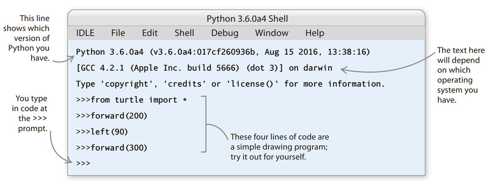

```python
from IPython import display
display.Image("C:/Users/John Hernandez/Documents/Rafael_DS_Sessions/console 1.png")
```

The **Text Editor** is where we start building programs that we want to save. Also, this is the place that permits us to see our code as a whole and not just line by line. Because it is not the shell it permits us to modify all of the parts of our program before executing and after running if an error is found, it will mention the line's number that we should need to repair. Due to its purpose of editing, this interface will change the color of our code depending on the function to permit its better understanding.

[figure not shown]

```python
from IPython import display
display.Image("C:/Users/John Hernandez/Documents/Rafael_DS_Sessions/textEditor.png")
```

#### Creating and Saving a Python file.

To create a Python file on the text editor you neeed to click on the *new (+)* button. After modifing your code or inmediatly after creating file, you can save the file by clicking *file-save* or the *save* button. You should give your file a appropiate name and ending it with the **.py** file's extension which will permit the computer understand that this is python file and will permit the Python's Idle to open it.

#### Comments

There are two basic ways to write comment in python:

- Single line commment start at every line with #
- Multiple line comment start and and with triple single qoute symbols '''

```python
# This is a single line commment
print("hello")
```

```
hello
```

```python
''' This is a
multiple line commment '''
print("hello")
```

```
hello
```

As you can see, in the previous two lines, comments are just for the programmer, the computer can not see them!

#### First Program

```python
print("Hello world")
```

```
Hello world
```

This program is the easiiest and most popular across any programming language, its permits yo to print something in the screen.

##### Using quotation properly

In our first program we used the function *print()* as an output function to print something on the screen. Since we just want to use text we were actually printing a *string*. To do so we can use single or double quotation mark at the beginning and end of the string (list of characters).

```python
#Right: using single quotation
print('Hello Rafael')

#Rigth: Using double quotation
print("Hello Rafael")
```

```
Hello Rafael
Hello Rafael
```

```python
#Wrong: using both at the same time
print('Hello Rafael")
```

```
  File "<ipython-input-19-af18fbb68c71>", line 2
    print('Hello Rafael")
                         ^
SyntaxError: EOL while scanning string literal
```